# Weather and Corn Yield Regressions

Kaydee Barker

2/28/2022

## Weather Data Analysis

### Load the PRISM daily maximum temperatures

```r
# daily max temperature
# dimensions: counties x days x years
prism <- readMat("prismiowa.mat")

# look at county #1
t_1981_c1 <- prism$tmaxdaily.iowa[1,,1] #first county, all days, first year
t_1981_c1[366] #check for leap year (366 days)
```

```
## [1] NaN
```

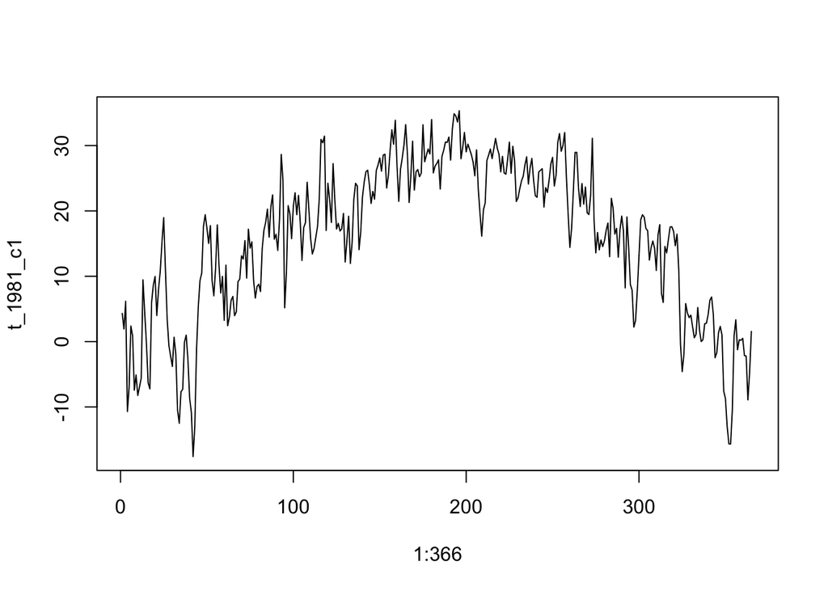

```r
plot(1:366, t_1981_c1, type = "l") #base r plot
```

```r
# assign dimension names to tmax matrix
dimnames(prism$tmaxdaily.iowa) <- list(prism$COUNTYFP, 1:366, prism$years) #add dimension names

# converted 3d matrix into a data frame
tmaxdf <- as.data.frame.table(prism$tmaxdaily.iowa)

# relabel the columns
colnames(tmaxdf) <- c("countyfp","doy","year","tmax") #name columns
tmaxdf <- tibble(tmaxdf) #tidyverse table
```

### Download NASS corn yield data

```r
# set our API key with NASS
nassqs_auth(key = "B9113AF8-85C4-3CEE-8D93-6E885D49E24F") #Here put in API code from USDA QuickStats service

# parameters to query on
params <- list(commodity_desc = "CORN", util_practice_desc = "GRAIN", prodn_practice_desc = "ALL PRODUCTION PRACTICES", year__GE = 1981, state_alpha = "IA")

# download
cornyieldsall <- nassqs_yields(params)
cornyieldsall$county_ansi <- as.numeric(cornyieldsall$county_ansi)
cornyieldsall$yield <- as.numeric(cornyieldsall$Value)

# clean and filter this dataset
cornyields <- select(cornyieldsall, county_ansi, county_name, yield, year) %>%
  filter(!is.na(county_ansi) & !is.na(yield))
cornyields <- tibble(cornyields)
```

## Assignment

### Question 1a: Extract Winneshiek County corn yields, fit a linear time trend, make a plot. Is there a significant time trend?

```r
winnecorn <- cornyields %>%
  filter(county_ansi == "191")

cornlm <- lm(yield ~ year, data = winnecorn)
summary(cornlm) #P=1.77e-13 R^2= 0.755
```

```
##
## Call:
## lm(formula = yield ~ year, data = winnecorn)
##
## Residuals:
##     Min      1Q  Median      3Q     Max
## -51.163  -1.841   2.363   9.437  24.376
##
## Coefficients:
##              Estimate Std. Error t value Pr(>|t|)
## (Intercept) -4763.290    448.286  -10.63 4.46e-13 ***
## year            2.457      0.224   10.96 1.77e-13 ***
## ---
## Signif. codes:  0 '***' 0.001 '**' 0.01 '*' 0.05 '.' 0.1 ' ' 1
##
## Residual standard error: 16.97 on 39 degrees of freedom
## Multiple R-squared:  0.7551, Adjusted R-squared:  0.7488
## F-statistic: 120.2 on 1 and 39 DF,  p-value: 1.767e-13
```

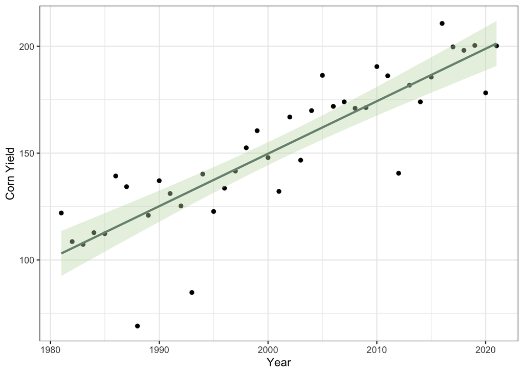

```r
ggplot(winnecorn, mapping = aes(x = year, y = yield)) +
  geom_point() +
  theme_bw() +
  labs(x = "Year", y = "Corn Yield") +
  geom_smooth(method = lm, se=TRUE, color="#78917E", fill="#C5DDB3")
```

**Figure 1.** Linear regression of corn yields over time (years) in Winneshieck County, Iowa.

There is a significant positive correlation between corn yields and years in Winneshieck County, with an R-squared value of 0.755 and a P-value of 1.77e-13.

### Question 1b: Fit a quadratic time trend (i.e., year + year^2) and make a plot. Is there evidence for slowing yield growth?

```r
winnecorn$yearsq <- winnecorn$year^2 #square explanatory variables for quadratic

lm_cornquad <- lm(yield ~ year + yearsq, winnecorn)
summary(lm_cornquad)
```

```
##
## Call:
## lm(formula = yield ~ year + yearsq, data = winnecorn)
##
## Residuals:
##     Min      1Q  Median      3Q     Max
## -51.384  -3.115   1.388   9.743  25.324
##
## Coefficients:
##               Estimate Std. Error t value Pr(>|t|)
## (Intercept)  2.583e+04  8.580e+04   0.301    0.765
## year        -2.812e+01  8.576e+01  -0.328    0.745
## yearsq       7.641e-03  2.143e-02   0.357    0.723
##
## Residual standard error: 17.17 on 38 degrees of freedom
## Multiple R-squared:  0.7559, Adjusted R-squared:  0.7431
## F-statistic: 58.84 on 2 and 38 DF,  p-value: 2.311e-12
```

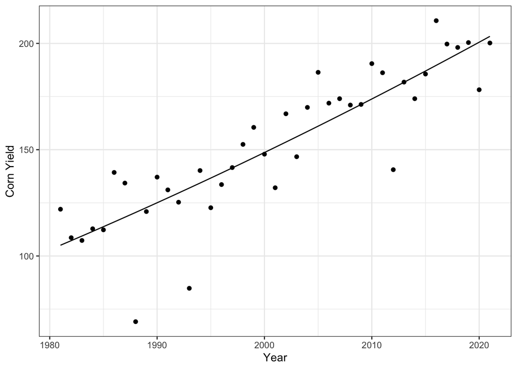

```r
winnecorn$y_fitted <- lm_cornquad$fitted.values

#with the fitted values, create a non-linear trend
ggplot(winnecorn) +
  geom_point(mapping = aes(x = year, y = yield)) +
  geom_line(mapping = aes(x = year, y = y_fitted)) +
  theme_bw() +
  labs(x = "Year", y = "Corn Yield")
```

**Figure 2.** Quadratic fit of corn yields over time (years) in Winneshieck County, Iowa.

When we fit a quadratic line to the data, we find that it follows very closely to a linear regression, suggesting a fairly linear relationship between corn yields and years in Winneshieck County. There is no evidence of slowing yield growth in the model.

### Question 2 – Time Series: Let’s analyze the relationship between temperature and yields for the Winneshiek County time series. Use data on yield and summer avg Tmax. Is adding year or Tmax^2 to your model helpful? Make a plot and interpret the results.

```r
# Winneshiek County summer temp maxes
tmaxdf$doy <- as.numeric(tmaxdf$doy)
tmaxdf$year <- as.numeric(as.character(tmaxdf$year))
tmaxdf$tmax <- as.numeric(tmaxdf$tmax)

winnesummer <- tmaxdf %>%
  filter(countyfp==191 & doy >= 152 & doy <= 243) %>% #day 152= June 1, 243= Aug 31
  group_by(year) %>%
  summarize(meantmax = mean(tmax))

lm_summertmax <- lm(meantmax ~ year, winnesummer)
summary(lm_summertmax) #not sig
```

```
##
## Call:
## lm(formula = meantmax ~ year, data = winnesummer)
##
## Residuals:
##     Min      1Q  Median      3Q     Max
## -2.5189 -0.7867 -0.0341  0.6859  3.7415
##
## Coefficients:
##             Estimate Std. Error t value Pr(>|t|)
## (Intercept) 41.57670   36.44848   1.141    0.262
## year        -0.00747    0.01823  -0.410    0.684
##
## Residual standard error: 1.232 on 36 degrees of freedom
## Multiple R-squared:  0.004644,   Adjusted R-squared:  -0.02301
## F-statistic: 0.168 on 1 and 36 DF,  p-value: 0.6844
```

```r
winnesummer$yearsq <- winnesummer$year^2 #square explanatory variables for quadratic
winnesummer$tmaxsq <- winnesummer$meantmax^2

lm_summerquad <- lm(meantmax ~ year + yearsq, winnesummer)
summary(lm_summerquad)
```

```
##
## Call:
## lm(formula = meantmax ~ year + yearsq, data = winnesummer)
##
## Residuals:
##     Min      1Q  Median      3Q     Max
## -2.4617 -0.8812 -0.0530  0.7204  3.7308
##
## Coefficients:
##               Estimate Std. Error t value Pr(>|t|)
## (Intercept)  3.618e+03  7.519e+03   0.481    0.633
## year        -3.585e+00  7.521e+00  -0.477    0.637
## yearsq       8.946e-04  1.881e-03   0.476    0.637
##
## Residual standard error: 1.246 on 35 degrees of freedom
## Multiple R-squared:  0.01104,    Adjusted R-squared:  -0.04547
## F-statistic: 0.1953 on 2 and 35 DF,  p-value: 0.8235
```

```r
winnesummer$t_fitted <- lm_summerquad$fitted.values

# Join yield and temp data
winne <- inner_join(winnecorn, winnesummer)
lmwinne <- lm(yield ~ yearsq + tmaxsq, data = winne)
summary(lmwinne)
```

```
##
## Call:
## lm(formula = yield ~ yearsq + tmaxsq, data = winne)
##
## Residuals:
##     Min      1Q  Median      3Q     Max
## -53.353  -7.496   2.089   9.806  27.874
##
## Coefficients:
##               Estimate Std. Error t value Pr(>|t|)
## (Intercept) -2.314e+03  2.557e+02  -9.047 1.09e-10 ***
## yearsq       6.274e-04  6.295e-05   9.968 9.22e-12 ***
## tmaxsq      -6.445e-02  4.245e-02  -1.518    0.138
## ---
## Signif. codes:  0 '***' 0.001 '**' 0.01 '*' 0.05 '.' 0.1 ' ' 1
##
## Residual standard error: 16.97 on 35 degrees of freedom
## Multiple R-squared:  0.7492, Adjusted R-squared:  0.7349
## F-statistic: 52.28 on 2 and 35 DF,  p-value: 3.074e-11
```

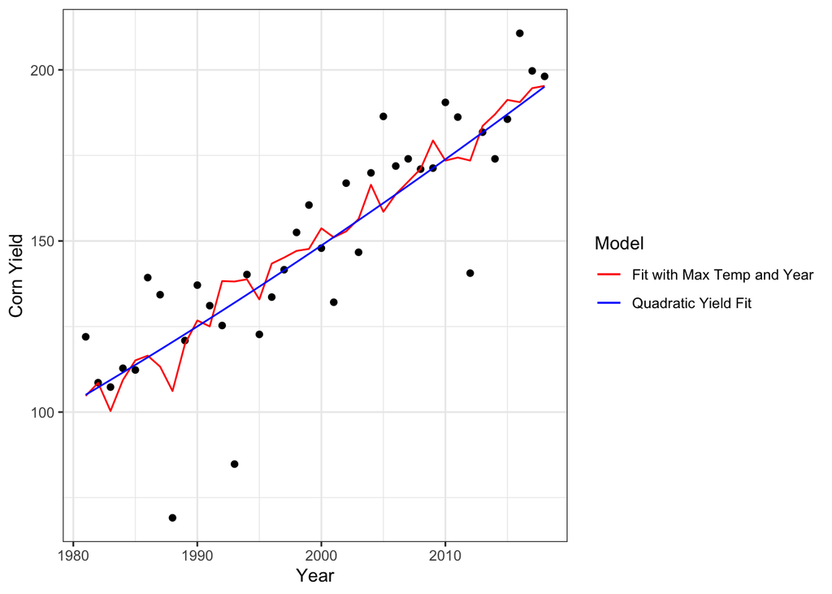

```r
winne$allfit <- lmwinne$fitted.values

ggplot(winne) +
  geom_point(mapping = aes(x = year, y = yield)) +
  geom_line(mapping = aes(x = year, y = allfit, color="red")) +
  geom_line(mapping = aes(x = year, y = y_fitted, color="blue")) +
  theme_bw() +
  scale_colour_manual(name = "Model",
         values =c("red"="red","blue"="blue"), labels = c("Fit with Max Temp and Year", "Quadratic Yield Fit")) +
  labs(x = "Year", y = "Corn Yield")
```

**Figure 3.** Comparative quadratic fit of corn yields over time (blue) and fitted line with maximum summer temperatures as well (red) in Winneshieck County, Iowa.

Adding maximum temperature trends to the model shows a similar trend, but peaks and dips in the fitted line highlight some of the outlying yield values and suggest an underlying relationship between maximum temperatures and yields. However, the relationship between squared maximum temperature and yield has a P-value of 0.14, compared with the year squared P-value of 9.22e-12, so it is clearly not the important driver of trends. This model has an R-squared value of 0.749, around the same as (slightly lower than) the simple linear regression model with only yield vs. year. Thus, adding temperature doesn’t significantly add to our understanding of yield trends in Winneshieck County.

### Question 3 – Cross-Section: Analyze the relationship between temperature and yield across all counties in 2018. Is there a relationship? Interpret the results.

```r
corn2018 <- cornyields %>%
  filter(year == "2018") %>%
  mutate_at(vars(county_ansi), funs(factor))

tmax2018 <- tmaxdf %>%
  filter(year == "2018") %>%
  filter(doy >= 152 & doy <= 243) %>%
  group_by(countyfp) %>%
  rename("county_ansi" = "countyfp") %>%
  summarize(meantmax = mean(tmax))

yieldtemp_2018 <- inner_join(corn2018, tmax2018, by="county_ansi") %>%
  mutate(tmaxsq = (meantmax^2))

yt_lm <- lm(yield ~ meantmax + tmaxsq, data = yieldtemp_2018)
summary(yt_lm)
```

```
##
## Call:
## lm(formula = yield ~ meantmax + tmaxsq, data = yieldtemp_2018)
##
## Residuals:
##     Min      1Q  Median      3Q     Max
## -44.221 -15.399   5.007  14.541  30.879
##
## Coefficients:
##              Estimate Std. Error t value Pr(>|t|)
## (Intercept) -5501.602   1860.830  -2.957  0.00397 **
## meantmax      406.789    131.493   3.094  0.00263 **
## tmaxsq         -7.256      2.321  -3.126  0.00239 **
## ---
## Signif. codes:  0 '***' 0.001 '**' 0.01 '*' 0.05 '.' 0.1 ' ' 1
##
## Residual standard error: 18.75 on 90 degrees of freedom
## Multiple R-squared:  0.1317, Adjusted R-squared:  0.1124
## F-statistic: 6.827 on 2 and 90 DF,  p-value: 0.001736
```

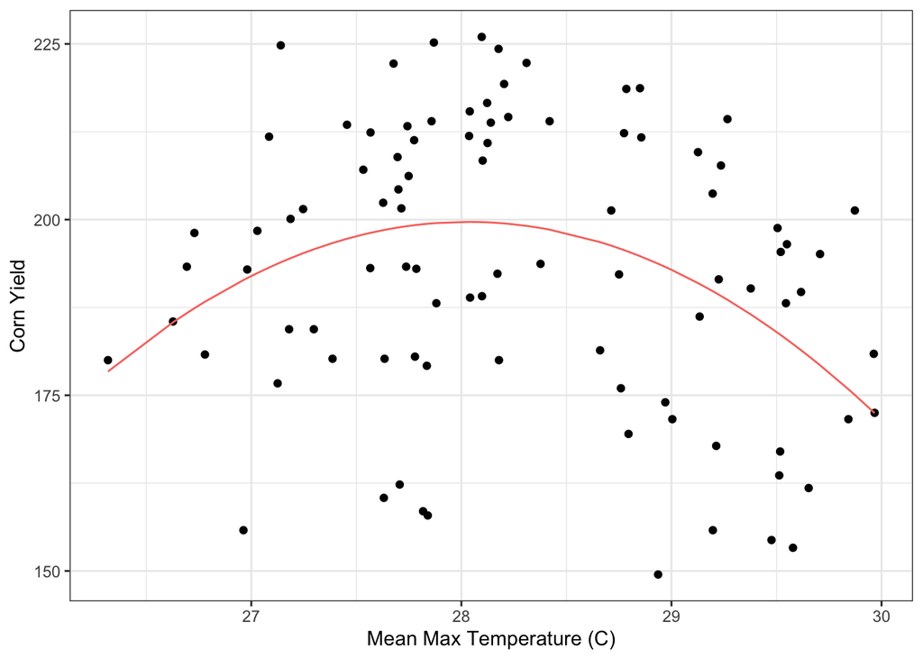

```r
yieldtemp_2018$ytfit <- yt_lm$fitted.values

ggplot(yieldtemp_2018) +
  geom_point(mapping = aes(x = meantmax, y = yield)) +
  geom_line(mapping = aes(x = meantmax, y = ytfit, color="red")) +
  theme_bw() + theme(legend.position="none") +
  labs(x = "Mean Max Temperature (C)", y = "Corn Yield")
```

**Figure 4.** Quadratic fit of corn yields versus maximum summer temperatures (Degrees C) across Iowa.

There is a clear relationship with maximum temperatures and corn yields demonstrated in Figure 4. As we might expect, there appears to be a “sweet spot” in regard to temperature, with corn crops performing best at moderate temperatures and yields falling off at both low and high temperature years. Lower mean maximum temperatures may indicate even lower temperatures that can shock crops, and high means are likely to cause high evaporation and withering. P<0.003 for the relationship between temperature and corn yield across Iowa.

### Question 4 – Panel: One way to leverage multiple time series is to group all data into what is called a “panel” regression. Convert the county ID code (“countyfp” or “county_ansi”) into factor using as.factor, then include this variable in a regression using all counties’ yield and summer temperature data. How does the significance of your temperature coefficients (Tmax, Tmax^2) change? Make a plot comparing actual and fitted yields and interpret the results of your model.

```r
corn_all <- cornyields %>%
  mutate_at(vars(county_ansi), funs(factor))

tmax_all <- tmaxdf %>%
  filter(doy >= 152 & doy <= 243) %>%
  group_by(countyfp, year) %>%
  rename("county_ansi" = "countyfp") %>%
  summarize(meantmax = mean(tmax))
yieldtemp_all <- inner_join(corn_all, tmax_all) %>%
  mutate(tmaxsq = (meantmax^2)) %>%
  mutate(yearsq = year^2)
ytc_lm <- lm(yield ~ year + meantmax + tmaxsq + county_ansi, data = yieldtemp_all)
summary(ytc_lm)
```

```
##
## Call:
## lm(formula = yield ~ year + meantmax + tmaxsq + county_ansi,
##     data = yieldtemp_all)
##
## Residuals:
##     Min      1Q  Median      3Q     Max
## -81.645  -9.720   1.924  13.232  40.409
##
## Coefficients:
##                  Estimate Std. Error t value Pr(>|t|)
## (Intercept)    -5.826e+03  9.804e+01 -59.431  < 2e-16 ***
## year            2.203e+00  2.836e-02  77.664  < 2e-16 ***
## meantmax        1.182e+02  6.108e+00  19.352  < 2e-16 ***
## tmaxsq         -2.225e+00  1.085e-01 -20.503  < 2e-16 ***
## county_ansi3   -4.527e+00  4.321e+00  -1.048 0.294839
## county_ansi5    2.716e+00  4.343e+00   0.625 0.531743
## county_ansi7   -1.828e+01  4.350e+00  -4.203 2.70e-05 ***
## county_ansi9    5.068e+00  4.323e+00   1.172 0.241144
## county_ansi11   7.186e+00  4.325e+00   1.661 0.096732 .
## county_ansi13   7.289e+00  4.329e+00   1.684 0.092303 .
## county_ansi15   1.498e+01  4.323e+00   3.466 0.000534 ***
## county_ansi17   1.133e+01  4.332e+00   2.615 0.008966 **
## county_ansi19   7.651e+00  4.334e+00   1.765 0.077577 .
## county_ansi21   8.640e+00  4.328e+00   1.996 0.045974 *
## county_ansi23   9.089e+00  4.327e+00   2.100 0.035779 *
## county_ansi25   1.039e+01  4.326e+00   2.401 0.016400 *
## county_ansi27   9.666e+00  4.323e+00   2.236 0.025421 *
## county_ansi29   6.145e+00  4.321e+00   1.422 0.155092
## county_ansi31   1.579e+01  4.324e+00   3.651 0.000264 ***
## county_ansi33   4.582e+00  4.338e+00   1.056 0.290980
## county_ansi35   1.390e+01  4.325e+00   3.213 0.001325 **
## county_ansi37   2.169e+00  4.341e+00   0.500 0.617274
## county_ansi39  -2.404e+01  4.350e+00  -5.527 3.48e-08 ***
## county_ansi41   6.611e+00  4.329e+00   1.527 0.126809
## county_ansi43   8.864e+00  4.337e+00   2.044 0.041033 *
## county_ansi45   1.055e+01  4.325e+00   2.439 0.014756 *
## county_ansi47   6.528e+00  4.324e+00   1.510 0.131221
## county_ansi49   1.081e+01  4.321e+00   2.502 0.012386 *
## county_ansi51  -1.457e+01  4.352e+00  -3.349 0.000820 ***
```

[output cut: 64 more lines]

```
## county_ansi181 -2.159e+00  4.321e+00  -0.500 0.617309
## county_ansi183  1.042e+01  4.321e+00   2.410 0.015981 *
## county_ansi185 -2.189e+01  4.350e+00  -5.033 5.07e-07 ***
## county_ansi187  1.421e+01  4.326e+00   3.285 0.001029 **
## county_ansi189  8.236e+00  4.344e+00   1.896 0.058035 .
## county_ansi191  4.567e+00  4.350e+00   1.050 0.293826
## county_ansi193  2.799e+00  4.321e+00   0.648 0.517252
## county_ansi195  6.123e+00  4.356e+00   1.406 0.159892
## county_ansi197  1.156e+01  4.329e+00   2.669 0.007634 **
## ---
## Signif. codes:  0 '***' 0.001 '**' 0.01 '*' 0.05 '.' 0.1 ' ' 1
##
## Residual standard error: 18.83 on 3646 degrees of freedom
## Multiple R-squared:  0.7207, Adjusted R-squared:  0.7129
## F-statistic: 93.13 on 101 and 3646 DF,  p-value: < 2.2e-16
```

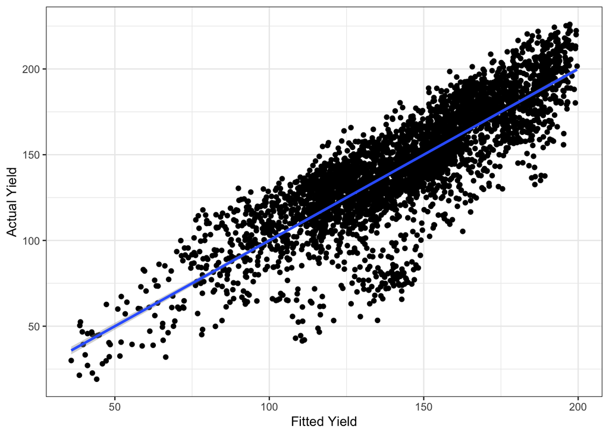

```r
yieldtemp_all$fittedyield <- ytc_lm$fitted.values

ggplot(yieldtemp_all, mapping = aes(x = fittedyield, y = yield)) +
  geom_point() +
  geom_smooth(method="lm") +
  theme_bw() + theme(legend.position="none") +
  labs(x = "Fitted Yield", y = "Actual Yield")
```

**Figure 5.** Fitted model yield values versus actual yield values for all counties of Iowa over all available years, from 1981 to 2018.

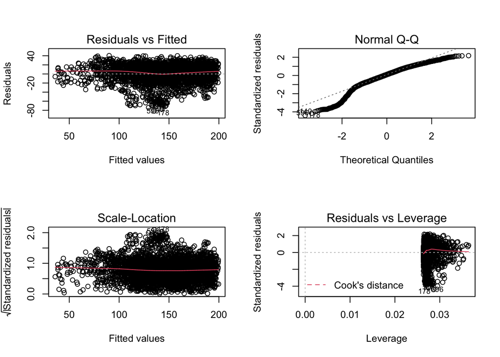

```r
par(mfrow=c(2,2))
plot(ytc_lm)
```

**Figure 6.** Residuals (top left), Normal Q-Q (top right), Scale-Location (bottom left), and Cook’s Distance (bottom right) plots for the panel regression model.

As a panel regression of all counties over all years, the statistical significance of year, mean maximum temperature, and squared maximum temperature as predictors of yield becomes stronger (P<2e-16 for each). The R squared value for the model is 0.721, indicating a pretty good fit, as is evident in Figure 5. However, the residuals for the model are pretty wide (Figures 5, 6) and the data may not be very normally distributed (Figure 6).

### Question 5 – Soybeans: Download NASS data on soybean yields and explore either a time series relationship for a given county, the cross-sectional relationship for a given year, or a panel across all counties and years.

```r
# parameters to query on
params2 <- list(commodity_desc = "SOYBEANS", prodn_practice_desc = "ALL PRODUCTION PRACTICES", year__GE = 1981, state_alpha = "IA")

# download
soyyieldsall <- nassqs_yields(params)
soyyieldsall$county_ansi <- as.numeric(soyyieldsall$county_ansi)
soyyieldsall$yield <- as.numeric(soyyieldsall$Value)

# clean and filter this dataset
soy <- select(soyyieldsall, county_ansi, county_name, yield, year) %>%
  filter(!is.na(county_ansi) & !is.na(yield))
soy <- tibble(soy)

soy_panel <- soy %>%
  mutate_at(vars(county_ansi), funs(factor)) %>%
  mutate(yearsq = year^2)

soypanel_lm <- lm(yield ~ year + yearsq + county_ansi, data = soy_panel)
summary(soypanel_lm)
```

```
##
## Call:
## lm(formula = yield ~ year + yearsq + county_ansi, data = soy_panel)
##
## Residuals:
##      Min       1Q   Median       3Q      Max
## -100.865   -9.428    3.328   14.357   54.326
##
## Coefficients:
##                  Estimate Std. Error t value Pr(>|t|)
## (Intercept)     4.646e+04  1.090e+04   4.263 2.06e-05 ***
## year           -4.859e+01  1.089e+01  -4.461 8.38e-06 ***
## yearsq          1.272e-02  2.722e-03   4.672 3.09e-06 ***
## county_ansi3   -3.974e+00  4.809e+00  -0.826 0.408591
## county_ansi5    1.128e+01  4.749e+00   2.376 0.017550 *
## county_ansi7   -1.878e+01  4.778e+00  -3.931 8.61e-05 ***
## county_ansi9    9.877e+00  4.749e+00   2.080 0.037621 *
## county_ansi11   1.206e+01  4.749e+00   2.539 0.011162 *
## county_ansi13   1.391e+01  4.749e+00   2.930 0.003413 **
## county_ansi15   1.785e+01  4.749e+00   3.759 0.000173 ***
## county_ansi17   1.899e+01  4.749e+00   3.998 6.50e-05 ***
## county_ansi19   1.609e+01  4.749e+00   3.389 0.000709 ***
## county_ansi21   1.519e+01  4.749e+00   3.198 0.001396 **
## county_ansi23   1.612e+01  4.749e+00   3.394 0.000696 ***
## county_ansi25   1.603e+01  4.749e+00   3.375 0.000744 ***
## county_ansi27   1.435e+01  4.749e+00   3.023 0.002523 **
## county_ansi29   7.386e+00  4.749e+00   1.555 0.119953
## county_ansi31   1.942e+01  4.749e+00   4.088 4.43e-05 ***
## county_ansi33   1.250e+01  4.749e+00   2.632 0.008515 **
## county_ansi35   1.961e+01  4.778e+00   4.105 4.13e-05 ***
## county_ansi37   1.127e+01  4.749e+00   2.373 0.017672 *
## county_ansi39  -2.380e+01  4.841e+00  -4.916 9.19e-07 ***
## county_ansi41   1.302e+01  4.749e+00   2.742 0.006141 **
## county_ansi43   1.659e+01  4.749e+00   3.493 0.000483 ***
## county_ansi45   1.556e+01  4.749e+00   3.276 0.001061 **
## county_ansi47   1.300e+01  4.749e+00   2.737 0.006228 **
## county_ansi49   1.131e+01  4.749e+00   2.382 0.017259 *
## county_ansi51  -1.838e+01  4.778e+00  -3.847 0.000121 ***
## county_ansi53  -1.681e+01  4.841e+00  -3.472 0.000521 ***
## county_ansi55   1.775e+01  4.749e+00   3.738 0.000188 ***
```

[output cut: 62 more lines]

```
## county_ansi181 -2.277e+00  4.809e+00  -0.473 0.635891
## county_ansi183  8.595e+00  4.778e+00   1.799 0.072137 .
## county_ansi185 -2.086e+01  4.778e+00  -4.365 1.30e-05 ***
## county_ansi187  2.017e+01  4.749e+00   4.247 2.21e-05 ***
## county_ansi189  1.687e+01  4.749e+00   3.552 0.000387 ***
## county_ansi191  1.306e+01  4.749e+00   2.750 0.005980 **
## county_ansi193  6.472e+00  4.749e+00   1.363 0.173049
## county_ansi195  1.503e+01  4.749e+00   3.164 0.001566 **
## county_ansi197  1.807e+01  4.749e+00   3.805 0.000144 ***
## ---
## Signif. codes:  0 '***' 0.001 '**' 0.01 '*' 0.05 '.' 0.1 ' ' 1
##
## Residual standard error: 21.37 on 3914 degrees of freedom
## Multiple R-squared:  0.6598, Adjusted R-squared:  0.6511
## F-statistic: 75.91 on 100 and 3914 DF,  p-value: < 2.2e-16
```

[figure not shown]

```r
soy_panel$fittedyield <- soypanel_lm$fitted.values

ggplot(soy_panel, mapping = aes(x = year, y = yield)) +
  geom_point() +
  geom_line(mapping = aes(x = year, y = fittedyield, color="red")) +
  geom_smooth(method="lm") +
  theme_bw() + theme(legend.position="none") +
  labs(x = "Year", y = "Soy Yield")
```

### Bonus: Find a package to make a county map of Iowa displaying some sort of information about yields or weather. Interpret your map.

```r
library(sf) #Spatial package that can read and create shapefiles
```

```r
library(mapview) #Interactive maps
library(USAboundaries) #USA states and counties

counties <- us_counties

Iowa_ct <- counties(states = 'iowa')
str(Iowa_ct)
```

```
## Classes 'sf' and 'data.frame':   99 obs. of  16 variables:
##  $ statefp          : chr  "19" "19" "19" "19" ...
##  $ countyfp         : chr  "001" "159" "005" "175" ...
##  $ countyns         : chr  "00465190" "00465268" "00465192" "00465276" ...
##  $ affgeoid         : chr  "0500000US19001" "0500000US19159" "0500000US19005" "0500000US19175" ...
##  $ geoid            : chr  "19001" "19159" "19005" "19175" ...
##  $ name             : chr  "Adair" "Ringgold" "Allamakee" "Union" ...
##  $ namelsad         : chr  "Adair County" "Ringgold County" "Allamakee County" "Union County" ...
##  $ stusps           : chr  "IA" "IA" "IA" "IA" ...
##  $ state_name       : chr  "Iowa" "Iowa" "Iowa" "Iowa" ...
##  $ lsad             : chr  "06" "06" "06" "06" ...
##  $ aland            : num  1.47e+09 1.39e+09 1.66e+09 1.10e+09 1.48e+09 ...
##  $ awater           : num  2597996 8723125 51094064 5575854 9099930 ...
##  $ state_name       : chr  "Iowa" "Iowa" "Iowa" "Iowa" ...
##  $ state_abbr       : chr  "IA" "IA" "IA" "IA" ...
##  $ jurisdiction_type: chr  "state" "state" "state" "state" ...
##  $ geometry         :sfc_MULTIPOLYGON of length 99; first list element: List of 1
##   ..$ :List of 1
##   .. ..$ : num [1:6, 1:2] -94.7 -94.2 -94.2 -94.5 -94.7 ...
##   ..- attr(*, "class")= chr [1:3] "XY" "MULTIPOLYGON" "sfg"
##  - attr(*, "sf_column")= chr "geometry"
##  - attr(*, "agr")= Factor w/ 3 levels "constant","aggregate",..: NA NA NA NA NA NA NA NA NA NA ...
##   ..- attr(*, "names")= chr [1:14] NA NA NA NA ...
```

```r
#mapview(Iowa_ct)

summer2018 <- tmaxdf %>%
  filter(doy >= 152 & doy <= 243, year==2018) %>% #day 152= June 1, 243= Aug 31
  group_by(countyfp, year) %>%
  summarize(meantmax = mean(tmax))
Itemp_2018 <- merge(Iowa_ct, summer2018)

mapview(Itemp_2018, zcol ='meantmax', col.regions=brewer.pal(9, "OrRd"), layer.name = "Mean Max. Summer Temp. (C)")
```

[interactive chart not shown]

**Figure 8.** Map of Iowa counties and their mean maximum temperatures in degrees Celsius during the summer of 2018.

This map demonstrates the spatial variation of temperature in the state of Iowa. With little topography impact, the northern part of the state experiences maximum highs that are 2-3 degrees (C) cooler than those experienced by the southern part of the state, respectively.